# Assignment 13

Gina Catellier

10/26/2020

#### NOTICE: Question 7 and 8 are optional.

1. Write a function to calculate the age of a person. Give an example to test your function.
- Input: a number, x, (year born)
- Output: Print out “You are r age”. Where r is the age of the person, i.e. 2020 - x.

Hint: [Similar Function](https://bryantstats.github.io/math421/gganimate/13_writing_functions.html#29)

```r
age <- function(x)
{
  r <- 2020 - x
  print(paste0('You are ', r, ' age.'))
}
```

```r
age(2000)
```

```
## [1] "You are 20 age."
```

2. Write the following function. Give an example to test your function.
- Input: a number
- Output: print out: “You input an even number!” if the number is event, or “You input an odd number!” otherwise.

Hint: [Similar Function](https://bryantstats.github.io/math421/gganimate/13_writing_functions.html#33)

```r
odd_even <- function(x)
{
  if(x %% 2==0)
  {
    print('You input an even number!')
  }
  else
  {
    print('You input an odd number!')
  }
}
```

```r
odd_even(3)
```

```
## [1] "You input an odd number!"
```

3. Write the following function. Give an example to test your function.
- Input: a numeric vector
- Output:
  - if the input vector has missing values: return the input vector with missing values replaced by mean
  - if the input vector has no missing value: return the same input vector

Hint: [Similar Function](https://bryantstats.github.io/math421/gganimate/13_writing_functions.html#37)

```r
mean_impute <- function(x)
{
    mean_of_x <- (mean(x, na.rm=TRUE))
    library(tidyr)
    x <- replace_na(x, mean_of_x)
    return(x)
}
```

```r
library(tidyverse)
df <- read_csv('titanic.csv')
x1 <- mean_impute(df$Age)
sum(is.na(x1))
```

```
## [1] 0
```

4. Write the following function. Give an example to test your function.
- Input: a vector x
- Output: The vector x where the missing values replaced by the mean (if x is numeric) or the mode (if x is non-numeric). If x does not have missing value, return the same vector x.

Hint: Combine the function in Question 3 and [this function](https://bryantstats.github.io/math421/gganimate/13_writing_functions.html#37)

```r
mean_mode_impute <- function(x)
{
  if(!is.numeric(x))
  {
    mode_of_x <- names(sort(-table(x)))[1]
    library(tidyr)
    x <- replace_na(x, mode_of_x)
  }
  else
  {
    mean_of_x <- (mean(x, na.rm=TRUE))
    library(tidyr)
    x <- replace_na(x, mean_of_x)
    return(x)
  }
}
```

```r
x2 <- mean_mode_impute(df$Embarked)
sum(is.na(x2))
```

```
## [1] 0
```

5. Write the following function. Give examples to test your function.
- Input: A data frame of two variables x and y
- Output:
- A boxplot of x by y (`aes(x = x, fill = y)`) if x is numeric and y is non-numeric
- A boxplot of y by x (`aes(x = x, fill = y)`) if y is numeric and x is non-numeric
- print out ‘This function cannot visualize your data’ otherwise

Hint:

- [Similar Function](https://bryantstats.github.io/math421/gganimate/13_writing_functions.html#41)
- You can refer to this slide to plot a boxplot: https://bryantstats.github.io/math421/slides/6_viz.html#36

```r
boxplot_function <- function(x)
{
  if(is.numeric(x[[1]])&(!(is.numeric(x[[2]]))))
  {
    x %>% ggplot(aes(x = x[[1]], fill = x[[2]]))+
      geom_boxplot()+
      labs(x = names(x)[1], fill = names(x)[2])
  }
  else if (!(is.numeric(x[[1]])|is.numeric(x[[2]])))
  {
    x %>% ggplot(aes(x = x[[2]], fill = x[[1]]))+
      geom_boxplot()+
      labs(x = names(x)[2], fill = names(x)[1])
  }
  else
  {
    print('This function cannot visualize your data.')
  }
}
```

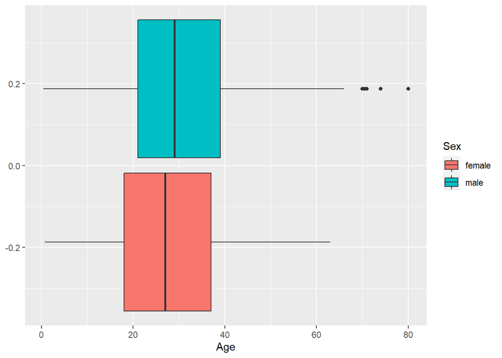

```r
example <- df %>% select(Age, Sex)
boxplot_function(example)
```

```r
boxplot_scatter_function <- function(x)
{
  if(is.numeric(x[[1]])&(!(is.numeric(x[[2]]))))
  {
    x %>% ggplot(aes(x = x[[1]], fill = x[[2]]))+
      geom_boxplot()+
      labs(x = names(x)[1], fill = names(x)[2])
  }
  else if (!(is.numeric(x[[1]])|is.numeric(x[[2]])))
  {
    x %>% ggplot(aes(x = x[[2]], fill = x[[1]]))+
      geom_boxplot()+
      labs(x = names(x)[2], fill = names(x)[1])
  }
  else if(is.numeric(x[[1]])&is.numeric(x[[2]]))
  {
    x %>% ggplot(aes(x = x[[1]], y = x[[2]]))+
      geom_point()+
      labs(x = names(x)[1], y = names(x)[2])
  }
  else if (!(is.numeric(x[[1]])|is.numeric(x[[2]])))
  {
    x %>% ggplot(aes(x = d[[1]], fill = x[[2]]))+
      geom_bar(position = 'dodge')+
      labs(x = names(x)[1], fill = names(x)[2])
  }
  else
  {
    print('This function cannot visualize your data.')
  }
}
```

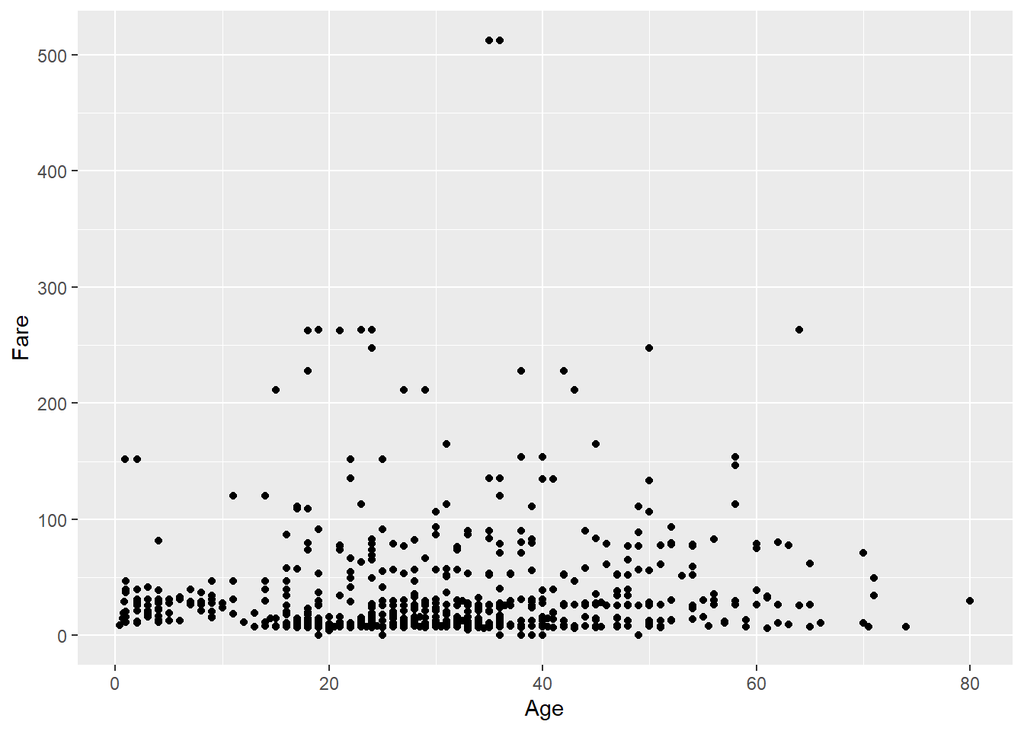

```r
example2 <- df %>% select(Age, Fare)
boxplot_scatter_function(example2)
```

```r
rpart_model <- function(input_data, train_percent = 0.8)
{
library(caret)
set.seed(00000)
splitIndex <- createDataPartition(input_data$target, p = train_percent, list = FALSE)
df_train <- input_data[ splitIndex,]
df_test <- input_data[-splitIndex,]
library(rpart)
tree1<-rpart(target ~ ., data = df_train)

library(rattle)
fancyRpartPlot(tree1)
}
```

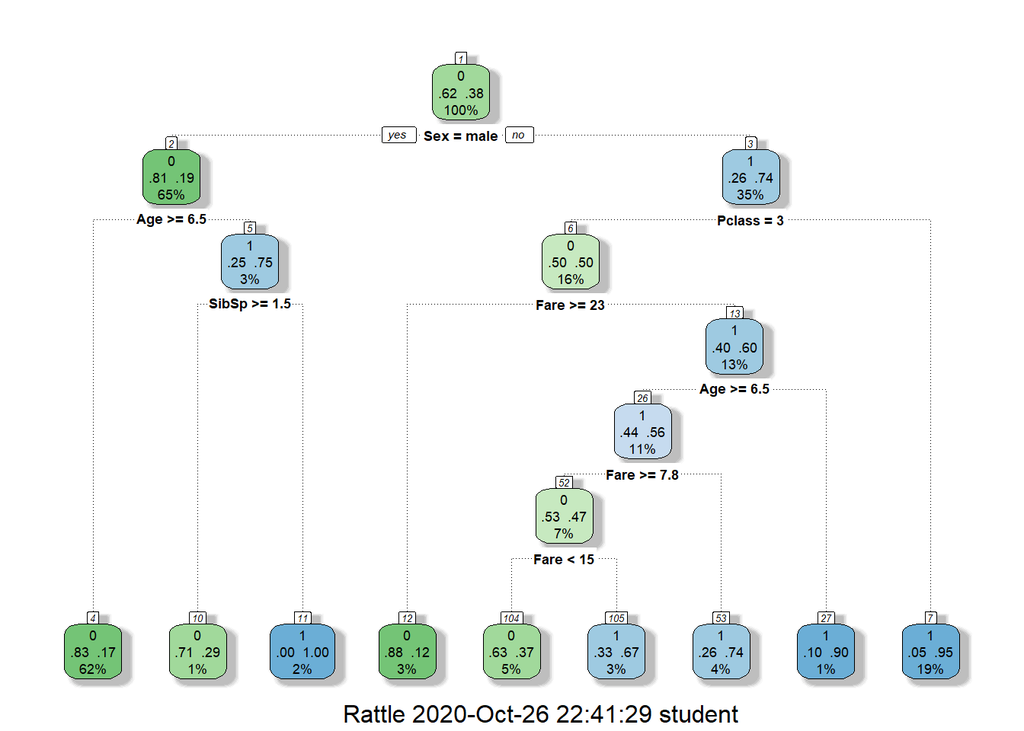

```r
df2 <- df
names(df2)[2] <- 'target'

df2$PassengerId =  NULL
df2$Ticket =  NULL
df2$Name = NULL
df2$Cabin = NULL

df2$target <- factor(df2$target)
df2$Pclass = factor(df2$Pclass)
df2$Sex <- factor(df2$Sex)
df2$Embarked <- factor(df2$Embarked)
df2$Parch <- factor(df2$Parch)

df2$Age[is.na(df2$Age)] = mean(df2$Age, na.rm = TRUE)
df2 = drop_na(df2)

rpart_model(df2, 0.8)
```

8. Write the following function. Give examples to test your function.
- Input:
  - input_data: a clean data frame with a variable name `target`. The `target` variable is also binary.
  - train_percent: a number presenting a proportion of training data. The default train_percent is .8
- Output: the plot of variable important by random forest trained by caret.

```r
random_forest_model <- function(input_data, train_percent=.8)
{
library(caret)
set.seed(00000)
splitIndex <- createDataPartition(input_data$target, p = train_percent, list = FALSE)
df_train <- input_data[ splitIndex,]
df_test <- input_data[-splitIndex,]
library(randomForest)
model = randomForest(target ~ ., data=df_train, ntree = 1000)

plot(importance(model))
}
```

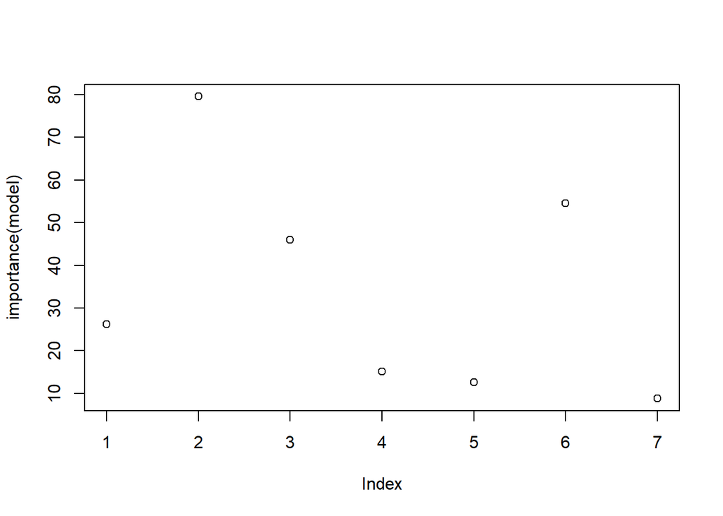

```r
random_forest_model(df2, 0.8)
```